# Data QA/QC Notebook on UNCORRECTED Raw Data

# Introduction

This notebook carries out some basic data QA/QC checks on the raw data. This version runs the QA/QC checks on the uncorrected data, to demonstrate the process used to identify problems. A second version of this notebook runs on the corrected data, to demonstrate the effect of the data correction process.

Note that this is based on analyzing the data already reorganized according to the code in the `Data Reorganization UNCORRECTED.Rmd` R notebook.

This version is outdated, and no longer being fully maintained but retained to help document data correction.

# Import Libraries

```r
library(readr)
library(tidyverse)
```

# Import Data

Note that we are loading an **uncorrected** file, not drawing directly from the Excel Source File. This file has been lightly processed to extract data from the Excel File, via the `Data_Reorganization_UNCORRECTED.Rmd` notebook.

```r
fn <- 'presumpscot_UNCORRECTED.csv'

presumpscot_data <- read_csv(fn,
    col_types = cols(Ecoli = col_double(),
                     X1 = col_skip()))
presumpscot_data <- presumpscot_data %>%
  select (-Time) %>%
  mutate(Month = factor(as.numeric(format(Date, '%m')),
                        labels = month.abb[5:9]))  # Note that as.numeric()
                                                   # will not give month number
```

# Data Prevalence

## *E.coli* data by year

```r
presumpscot_data %>%
  group_by(Site, Year)%>%
  summarize(n=sum(! is.na(Ecoli)))%>%
  spread(Year, n)
```

| Site | 2009 | 2010 | 2011 | 2012 | 2013 | 2014 | 2015 | 2016 | 2017 | 2018 | 2019 |
| --- | --- | --- | --- | --- | --- | --- | --- | --- | --- | --- | --- |
| BB010 | 5 | 7 | 6 | 7 | 8 | 9 | 8 | NA | 9 | 9 | 12 |
| BL010 | NA | NA | 7 | 8 | 7 | 9 | 8 | 2 | 10 | 9 | 8 |
| BL020 | NA | NA | NA | NA | NA | NA | NA | NA | 8 | 10 | 8 |
| CW010 | NA | NA | 7 | 9 | 8 | 9 | 7 | 2 | 3 | 10 | 10 |
| CW020 | NA | NA | 3 | NA | 10 | 10 | 7 | 2 | 4 | 10 | 10 |
| DB010 | 6 | 7 | 6 | 6 | 8 | 9 | 8 | 7 | 10 | 7 | NA |
| DG010 | 7 | 2 | 6 | NA | 8 | 10 | 8 | 5 | 11 | 7 | 9 |
| IN010 | NA | NA | 8 | 8 | NA | NA | NA | NA | 9 | 8 | 9 |
| L010 | 6 | 6 | 6 | 10 | NA | 10 | 8 | 9 | 11 | 10 | 9 |
| L020 | 4 | 4 | 5 | NA | NA | NA | NA | NA | 3 | 7 | 9 |

[output cut: 37 more lines]

## DO data by year

```r
presumpscot_data %>%
  group_by(Site, Year)%>%
  summarize(n=sum(! is.na(DO)))%>%
  spread(Year, n)
```

| Site | 2009 | 2010 | 2011 | 2012 | 2013 | 2014 | 2015 | 2016 | 2017 | 2018 | 2019 |
| --- | --- | --- | --- | --- | --- | --- | --- | --- | --- | --- | --- |
| BB010 | 6 | 6 | 7 | 6 | 8 | 8 | 7 | NA | 9 | 8 | 11 |
| BL010 | NA | NA | 8 | 8 | 8 | 8 | 8 | 2 | 10 | 9 | 8 |
| BL020 | NA | NA | NA | NA | NA | NA | NA | NA | 9 | 9 | 8 |
| CW010 | NA | NA | 8 | 9 | 9 | 8 | 8 | 2 | 5 | 10 | 10 |
| CW020 | NA | NA | 3 | NA | 8 | 9 | 8 | 2 | 6 | 10 | 10 |
| DB010 | 7 | 7 | 6 | 3 | 8 | 8 | 2 | 7 | 3 | 7 | NA |
| DG010 | 6 | 1 | 7 | NA | 8 | 10 | 8 | 5 | 12 | 7 | 10 |
| IN010 | NA | NA | 8 | 8 | NA | NA | NA | NA | 6 | 8 | 9 |
| L010 | 7 | 5 | 7 | 9 | NA | 10 | 8 | 8 | 1 | 9 | 9 |
| L020 | 6 | 4 | 7 | NA | NA | NA | NA | NA | 1 | 7 | 9 |

[output cut: 37 more lines]

Apparently, a total of 47 locations have been sampled by PRW since 2009. The normal sampling plan in each year is to sample a fixed number of Saturdays, usually eight. We often see more than eight sample records at a site within a year. Generally this is because QA/QC replicate samples were collected, or DO data were collected at different depths on one sample date. Multiple depth samples were only collected in 2011, 2012, and 2013.

Prior analysis has shown little effect of sample depth. There sometimes are substantial differences in observed E. coli values for replicate samples, expressed as a percent difference. On a log scale, however, the differences are less apparent.

## Create a “surface water only”" data set

Note that this is not necessary for E.Coli, but is for DO.

```r
surface_data <- presumpscot_data %>%
  filter(is.na(Depth) | Depth == 0)
```

### Review number of Samples

```r
cat('All Data\n')
```

```
All Data
```

```r
a <- with(presumpscot_data, cbind(length(Ecoli),
                             sum(! is.na(Ecoli)),
                             sum(! is.na(DO))))
colnames(a) <- c('N', 'E.coli', 'DO')
a
```

```
        N E.coli   DO
[1,] 2582   2339 2242
```

```r
cat('Surface Data\n')
```

```
Surface Data
```

```r
a <- with(surface_data, cbind(length(Ecoli),
                         sum(! is.na(Ecoli)),
                         sum(! is.na(DO))))
colnames(a) <- c('N', 'E.coli', 'DO')
a
```

```
        N E.coli   DO
[1,] 2480   2339 2140
```

```r
rm(a)
```

We lose approximately 100 samples, all affecting DO samples, not *E. coli* samples.

# Analysis of duplicates

This is for QA/QC purposes. We may want to look at variation among duplicates.

```r
duplicates = presumpscot_data %>%
  group_by(Date, Site) %>%
  mutate(nColi= sum(!is.na(Ecoli))) %>%
  ungroup() %>%
  filter(nColi>1) %>%
  mutate(SampleID = paste0(Site,'.',Date)) %>%
  arrange(Date) %>%
  select(SampleID, Site, Date, Year, Month, Ecoli, Flag, DO, PctSat)
```

```r
diffs <- duplicates %>%
  group_by(SampleID) %>%
  summarize(Year = min(Year),
            m = (max(Ecoli, na.rm=TRUE)+min(Ecoli, na.rm=TRUE))/2,
            d= max(Ecoli, na.rm=TRUE)-min(Ecoli, na.rm=TRUE),
            pctd = d/m)
  summary(diffs)
```

```
   SampleID              Year            m                d
 Length:159         Min.   :2009   Min.   :   3.6   Min.   :   0.00
 Class :character   1st Qu.:2011   1st Qu.:  37.0   1st Qu.:   3.40
 Mode  :character   Median :2014   Median : 132.6   Median :  18.40
                    Mean   :2014   Mean   : 321.4   Mean   :  78.21
                    3rd Qu.:2015   3rd Qu.: 320.4   3rd Qu.:  76.15
                    Max.   :2019   Max.   :2419.6   Max.   :1119.52
      pctd
 Min.   :0.00000
 1st Qu.:0.07889
 Median :0.17799
 Mean   :0.25561
 3rd Qu.:0.34971
 Max.   :1.86509
```

So, that shows that there are sometimes differences that are extremely large. A better analysis might be of logs of abundance, given the heavy skew of the observed data.

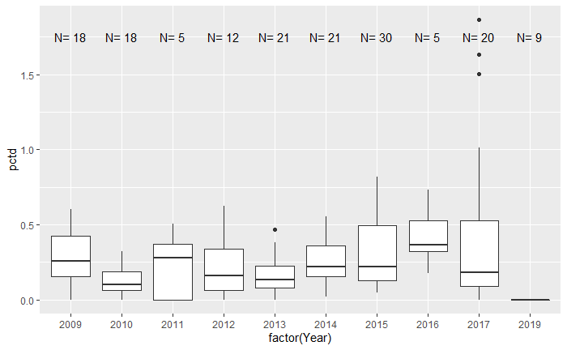

```r
ns = diffs %>%
  group_by(Year) %>%
  summarize(n=n()) %>%
  mutate(n2 = paste("N=", n))
ggplot(diffs, aes(factor(Year), pctd)) +
  geom_boxplot() +
  geom_text(aes(label=n2, x=factor(Year), y=1.75 ), data=ns)
```

So, the most extreme variation came from year 2017, and there were no duplicates in 2018, and few in 2019.

Given the skewed nature of these data, these high percent differences are not dreadful, but they don’t make anyone happy either. A percent difference of more than 150%, as observed three times in 2017, is problematic.

But notice the differences observed in 2019:

```r
diffs %>%
  filter(Year==2019) %>% pull(d)
```

```
[1] 0 0 0 0 0 0 0 0 0
```

That is clearly an error of some kind. I eventually corrected those, which appear to be spurious duplicate E. coli observations, by removing one of each pair of identical E. coli observations, while leaving in place the different DO observations reported.

# Data Evaluation

## E Coli QA/QC Review

### Histograms

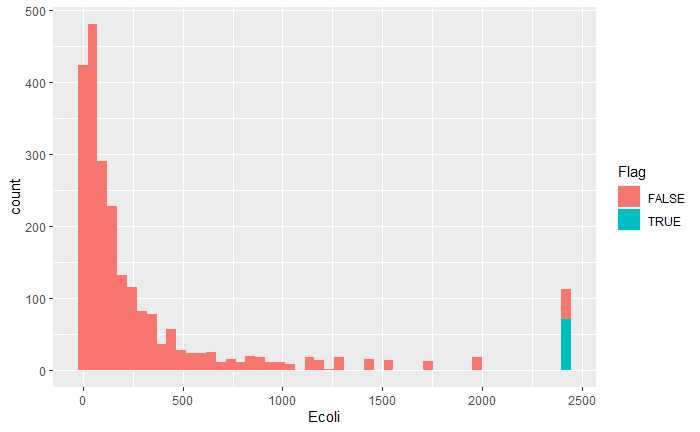

```r
plt <- ggplot(presumpscot_data, aes(Ecoli)) +
  geom_histogram(aes(fill = Flag), bins=50) #+
  #geom_density()
plt
```

Notice that the values, while conceptually continuous are converted to select discrete values by the MPN method used. Technically this is interval censored data, but there are so many categories that the impact on analysis is probably small.

The number of “uncensored” large values looks implausibly high, and a close look shows that several slightly different values are all included with NEARLY identical values. I suspect that reflects different coding practices over time. Again, differences are too small to matter for any quantitative analysis, so we leave all observations as is.

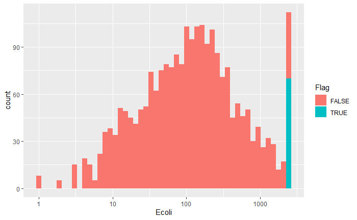

```r
plt  + scale_x_log10()
```

We have a fat tailed mound-like distribution, which suggests a lognormal distribution may work well for these data. But note also that we have an excess of elevated values, if we think this follows a lognormal distribution. An alternative is a Pareto Distribution, which also fits these data fairly well. The Pareto predicts more extreme values than the lognormal. (see the analysis notebooks for more details).

# Plotting Relationship with DO

We are looking here for any outliers.

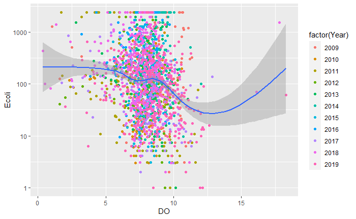

```r
plt <- ggplot(surface_data, aes(DO, Ecoli)) +
  geom_point(aes(color=factor(Year))) +
  geom_smooth() +
  scale_y_log10()
plt
```

Other than a few extreme DO values, there is nothing obviously amiss here. There is a weak indication that higher DO is associated with lower E. coli, as might be expected if summer low flows and high temperatures are bad for both dissolved oxygen and bacteria loads. We can do little more with this based on these data because we lack temperature data for 2018 and 2019.

## DO QA/QC Review

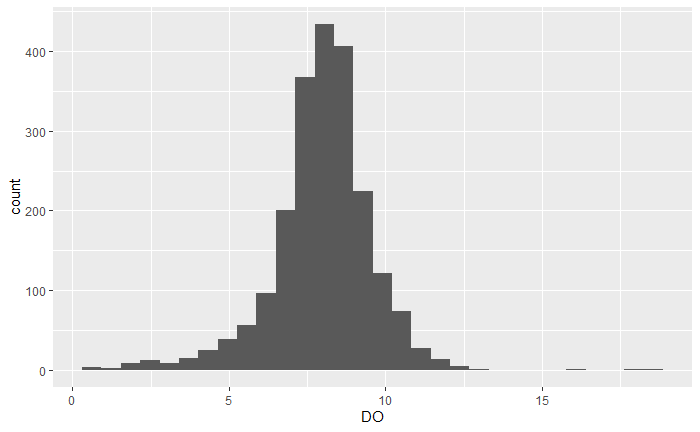

```r
plt <- ggplot(surface_data, aes(DO)) + geom_histogram()
plt
```

We notice a few implausible low and a few implausible high DO observations.

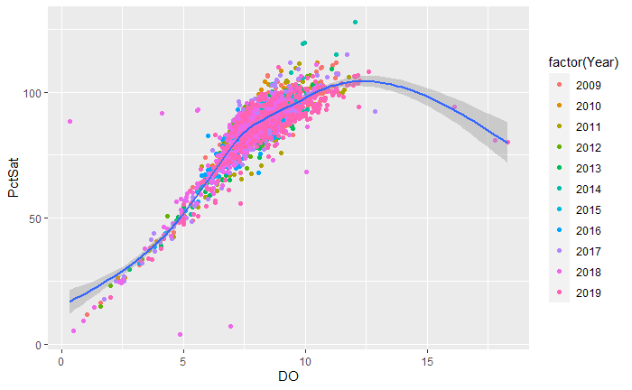

```r
plt <- ggplot(surface_data, aes(DO, PctSat)) +
  geom_point(aes(color =factor(Year))) +
  geom_smooth()
plt
```

Note a handful of observations that are far from the trendline. Most are from 2018. A couple are also from 2014, and one from 2019. Lets explore those.

```r
anomolies <- surface_data %>%
  filter((PctSat>75 & (DO<6 | DO>13)) | (PctSat<25 & DO>4 ) | PctSat>115) %>%
  select(-Name, -QC, -Depth, -Flag, -Month)
anomolies
```

| Site | Year | Date | Temp | DO | PctSat | Ecoli |
| --- | --- | --- | --- | --- | --- | --- |
| M030 | 2014 | 2014-07-12 | 24.4 | 9.9600000 | 119.40 | 42.20 |
| M030 | 2014 | 2014-07-12 | 24.5 | 9.9200000 | 119.20 | 43.50 |
| PI020 | 2014 | 2014-07-12 | 18.2 | 12.0400000 | 127.70 | 101.70 |
| PI020 | 2018 | 2018-05-19 | NA | 16.1100000 | 94.10 | 69.70 |
| OB020 | 2018 | 2018-06-17 | NA | 4.8800000 | 4.10 | 248.90 |
| DB010 | 2018 | 2018-07-01 | NA | 5.5900000 | 93.10 | 1046.24 |
| PL040 | 2018 | 2018-07-01 | NA | 5.5800000 | 92.60 | 1119.85 |
| BB010 | 2018 | 2018-07-15 | NA | 4.1200000 | 91.50 | 155.30 |
| M010 | 2018 | 2018-07-15 | NA | 0.3555556 | 88.40 | 435.20 |
| CW020 | 2018 | 2018-07-29 | NA | 17.8000000 | 80.80 | 1553.10 |

[output cut: 2 more lines]

```r
#write.csv(anomolies,"anomolies.csv")
```

Careful review shows many of these represent implausible of DO and Percent Saturation. I sent a modified list of likely errors to Toby, who passed them on to DEP, who returned suggested corrections to the 2018 data, based on DEP’s QA/QC procedures.